# travel-project

### Look at Super Deluxe Buyers

```python
sup_deluxe = taken_data[taken_data['ProductPitched'] == 'Super Deluxe']
sup_deluxe.shape
```

```
(19, 19)
```

```python
rej_sup_deluxe = data[data['ProductPitched'] == 'Super Deluxe']
rej_sup_deluxe.shape
```

```
(250, 19)
```

```python
19/250
```

```
0.076
```

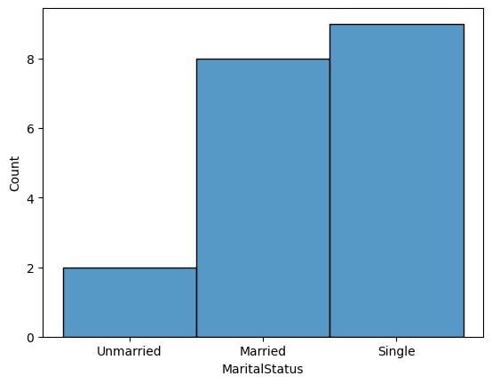

```python
#Lets look at marrige as it relates to this ProductPitched
sns.histplot(data=sup_deluxe, x="MaritalStatus")
```

Married and single people should be focused on for deluxe packages

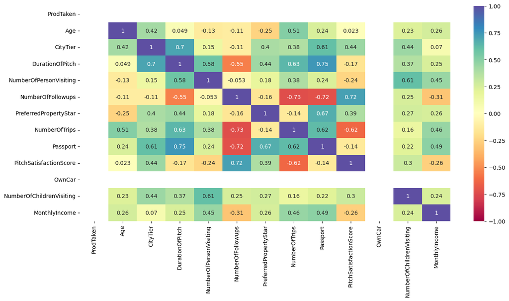

```python
plt.figure(figsize=(15,7))
sns.heatmap(sup_deluxe.corr(),annot=True,vmin=-1,vmax=1,cmap="Spectral")
plt.show()
```

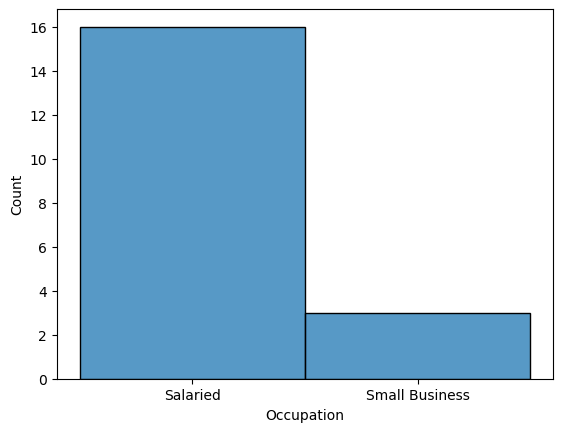

```python
sns.histplot(data=sup_deluxe, x="Occupation")
```

Salaried persons should be focused on for deluxe packages

### Look at Super King Buyers

```python
king = taken_data[taken_data['ProductPitched'] == 'King']
king.shape
```

```
(9, 19)
```

```python
rej_king = data[data['ProductPitched'] == 'King']
rej_king.shape
```

```
(104, 19)
```

```python
9/104
```

```
0.08653846153846154
```

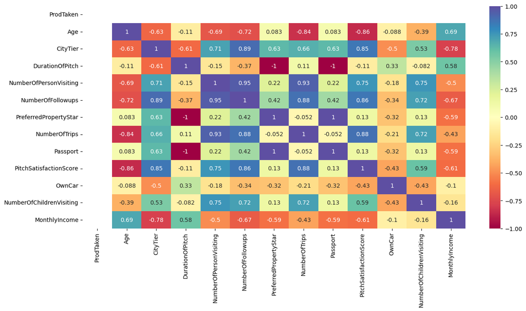

```python
plt.figure(figsize=(15,7))
sns.heatmap(king.corr(),annot=True,vmin=-1,vmax=1,cmap="Spectral")
plt.show()
```

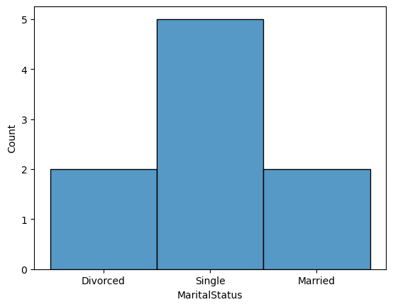

```python
sns.histplot(data=king, x="MaritalStatus")
```

Single people should be targeted for King packages

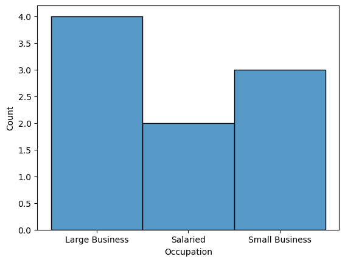

```python
sns.histplot(data=king, x="Occupation")
```

Large and small businesses should be targeted for large packages

```python
### More EDA using techniques and methods used in course work
```

```python
# function to plot a boxplot and a histogram along the same scale.


# def histogram_boxplot(data, feature, figsize=(12, 7), kde=False, bins=None):
#     """
#     Boxplot and histogram combined

#     data: dataframe
#     feature: dataframe column
#     figsize: size of figure (default (12,7))
#     kde: whether to show the density curve (default False)
#     bins: number of bins for histogram (default None)
#     """
#     f2, (ax_box2, ax_hist2) = plt.subplots(
#         nrows=2,  # Number of rows of the subplot grid= 2
#         sharex=True,  # x-axis will be shared among all subplots
#         gridspec_kw={"height_ratios": (0.25, 0.75)},
#         figsize=figsize,
#     )  # creating the 2 subplots
#     sns.boxplot(
#         data=data, x=feature, ax=ax_box2, showmeans=True, color="violet"
#     )  # boxplot will be created and a star will indicate the mean value of the column
#     sns.histplot(
#         data=data, x=feature, kde=kde, ax=ax_hist2, bins=bins, palette="winter"
#     ) if bins else sns.histplot(
#         data=data, x=feature, kde=kde, ax=ax_hist2
#     )  # For histogram
#     ax_hist2.axvline(
#         data[feature].mean(), color="green", linestyle="--"
#     )  # Add mean to the histogram
#     ax_hist2.axvline(
#         data[feature].median(), color="black", linestyle="-"
#     )  # Add median to the histogram
```

```python
# function to create labeled barplots


# def labeled_barplot(data, feature, perc=False, n=None):
#     """
#     Barplot with percentage at the top

#     data: dataframe
#     feature: dataframe column
#     perc: whether to display percentages instead of count (default is False)
#     n: displays the top n category levels (default is None, i.e., display all levels)
#     """

#     total = len(data[feature])  # length of the column
#     count = data[feature].nunique()
#     if n is None:
#         plt.figure(figsize=(count + 1, 5))
#     else:
#         plt.figure(figsize=(n + 1, 5))

#     plt.xticks(rotation=90, fontsize=15)
#     ax = sns.countplot(
#         data=data,
#         x=feature,
#         palette="Paired",
#         order=data[feature].value_counts().index[:n].sort_values(),
#     )

#     for p in ax.patches:
#         if perc == True:
#             label = "{:.1f}%".format(
#                 100 * p.get_height() / total
#             )  # percentage of each class of the category
#         else:
#             label = p.get_height()  # count of each level of the category

#         x = p.get_x() + p.get_width() / 2  # width of the plot
#         y = p.get_height()  # height of the plot

#         ax.annotate(
#             label,
#             (x, y),
#             ha="center",
#             va="center",
#             size=12,
#             xytext=(0, 5),
#             textcoords="offset points",
#         )  # annotate the percentage

#     plt.show()  # show the plot
```

```python
# function to plot stacked bar chart


# def stacked_barplot(data, predictor, target):
#     """
#     Print the category counts and plot a stacked bar chart

#     data: dataframe
#     predictor: independent variable
#     target: target variable
#     """
#     count = data[predictor].nunique()
#     sorter = data[target].value_counts().index[-1]
#     tab1 = pd.crosstab(data[predictor], data[target], margins=True).sort_values(
#         by=sorter, ascending=False
#     )
#     print(tab1)
#     print("-" * 120)
#     tab = pd.crosstab(data[predictor], data[target], normalize="index").sort_values(
#         by=sorter, ascending=False
#     )
#     tab.plot(kind="bar", stacked=True, figsize=(count + 1, 5))
#     plt.legend(
#         loc="lower left",
#         frameon=False,
#     )
#     plt.legend(loc="upper left", bbox_to_anchor=(1, 1))
#     plt.show()
```

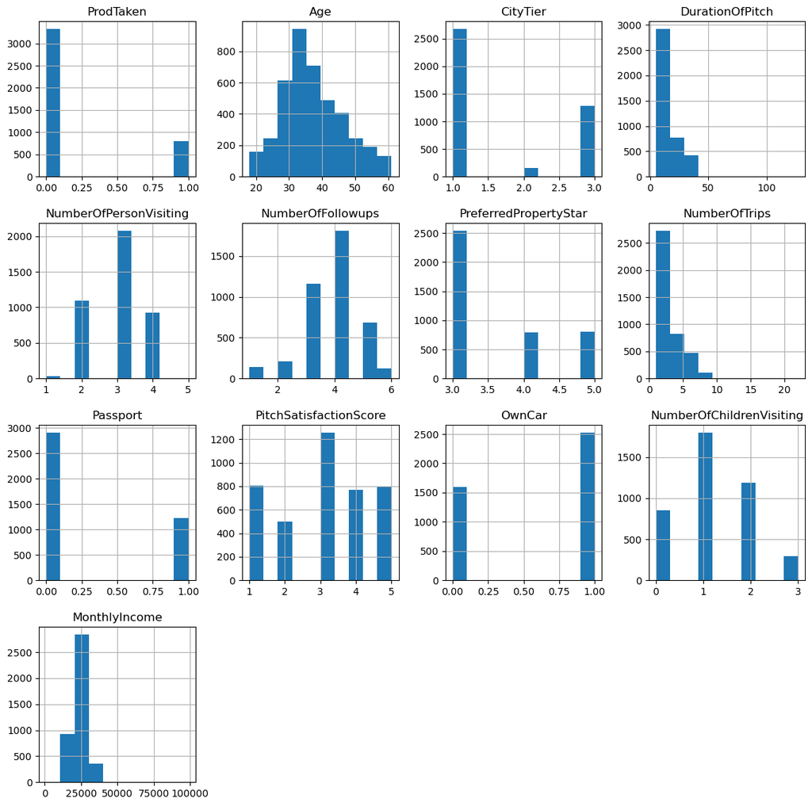

```python
#multiple histogram creation
data.hist(figsize=(14, 14))
plt.show()
```

Several interesting instights here:

- Number of follow ups is left scewed
- Number of trips right scewed
- Age is normally distributed

## Data Pre Processing

*note we dropped nas earlier

```python
data.info()
```

```
<class 'pandas.core.frame.DataFrame'>
Int64Index: 4128 entries, 0 to 4887
Data columns (total 19 columns):
 #   Column                    Non-Null Count  Dtype
---  ------                    --------------  -----
 0   ProdTaken                 4128 non-null   int64
 1   Age                       4128 non-null   float64
 2   TypeofContact             4128 non-null   object
 3   CityTier                  4128 non-null   int64
 4   DurationOfPitch           4128 non-null   float64
 5   Occupation                4128 non-null   object
 6   Gender                    4128 non-null   object
 7   NumberOfPersonVisiting    4128 non-null   int64
 8   NumberOfFollowups         4128 non-null   float64
 9   ProductPitched            4128 non-null   object
 10  PreferredPropertyStar     4128 non-null   float64
 11  MaritalStatus             4128 non-null   object
 12  NumberOfTrips             4128 non-null   float64
 13  Passport                  4128 non-null   int64
 14  PitchSatisfactionScore    4128 non-null   int64
 15  OwnCar                    4128 non-null   int64
 16  NumberOfChildrenVisiting  4128 non-null   float64
 17  Designation               4128 non-null   object
 18  MonthlyIncome             4128 non-null   float64
dtypes: float64(7), int64(6), object(6)
memory usage: 774.0+ KB
```

```python
data.head()
```

|  | ProdTaken | Age | TypeofContact | CityTier | DurationOfPitch | Occupation | Gender | NumberOfPersonVisiting | NumberOfFollowups | ProductPitched | PreferredPropertyStar | MaritalStatus | NumberOfTrips | Passport | PitchSatisfactionScore | OwnCar | NumberOfChildrenVisiting | Designation | MonthlyIncome |
| --- | --- | --- | --- | --- | --- | --- | --- | --- | --- | --- | --- | --- | --- | --- | --- | --- | --- | --- | --- |
| 0 | 1 | 41.0 | Self Enquiry | 3 | 6.0 | Salaried | Female | 3 | 3.0 | Deluxe | 3.0 | Single | 1.0 | 1 | 2 | 1 | 0.0 | Manager | 20993.0 |
| 1 | 0 | 49.0 | Company Invited | 1 | 14.0 | Salaried | Male | 3 | 4.0 | Deluxe | 4.0 | Divorced | 2.0 | 0 | 3 | 1 | 2.0 | Manager | 20130.0 |
| 2 | 1 | 37.0 | Self Enquiry | 1 | 8.0 | Free Lancer | Male | 3 | 4.0 | Basic | 3.0 | Single | 7.0 | 1 | 3 | 0 | 0.0 | Executive | 17090.0 |
| 3 | 0 | 33.0 | Company Invited | 1 | 9.0 | Salaried | Female | 2 | 3.0 | Basic | 3.0 | Divorced | 2.0 | 1 | 5 | 1 | 1.0 | Executive | 17909.0 |
| 5 | 0 | 32.0 | Company Invited | 1 | 8.0 | Salaried | Male | 3 | 3.0 | Basic | 3.0 | Single | 1.0 | 0 | 5 | 1 | 1.0 | Executive | 18068.0 |

```python
#perform one hot encoding
data = pd.get_dummies(data, columns=["TypeofContact","Occupation","Gender","ProductPitched","MaritalStatus", "Designation"],drop_first=True)
data
```

|  | ProdTaken | Age | CityTier | DurationOfPitch | NumberOfPersonVisiting | NumberOfFollowups | PreferredPropertyStar | NumberOfTrips | Passport | PitchSatisfactionScore | ... | ProductPitched_King | ProductPitched_Standard | ProductPitched_Super Deluxe | MaritalStatus_Married | MaritalStatus_Single | MaritalStatus_Unmarried | Designation_Executive | Designation_Manager | Designation_Senior Manager | Designation_VP |
| --- | --- | --- | --- | --- | --- | --- | --- | --- | --- | --- | --- | --- | --- | --- | --- | --- | --- | --- | --- | --- | --- |
| 0 | 1 | 41.0 | 3 | 6.0 | 3 | 3.0 | 3.0 | 1.0 | 1 | 2 | ... | 0 | 0 | 0 | 0 | 1 | 0 | 0 | 1 | 0 | 0 |
| 1 | 0 | 49.0 | 1 | 14.0 | 3 | 4.0 | 4.0 | 2.0 | 0 | 3 | ... | 0 | 0 | 0 | 0 | 0 | 0 | 0 | 1 | 0 | 0 |
| 2 | 1 | 37.0 | 1 | 8.0 | 3 | 4.0 | 3.0 | 7.0 | 1 | 3 | ... | 0 | 0 | 0 | 0 | 1 | 0 | 1 | 0 | 0 | 0 |
| 3 | 0 | 33.0 | 1 | 9.0 | 2 | 3.0 | 3.0 | 2.0 | 1 | 5 | ... | 0 | 0 | 0 | 0 | 0 | 0 | 1 | 0 | 0 | 0 |
| 5 | 0 | 32.0 | 1 | 8.0 | 3 | 3.0 | 3.0 | 1.0 | 0 | 5 | ... | 0 | 0 | 0 | 0 | 1 | 0 | 1 | 0 | 0 | 0 |
| ... | ... | ... | ... | ... | ... | ... | ... | ... | ... | ... | ... | ... | ... | ... | ... | ... | ... | ... | ... | ... | ... |
| 4883 | 1 | 49.0 | 3 | 9.0 | 3 | 5.0 | 4.0 | 2.0 | 1 | 1 | ... | 0 | 0 | 0 | 0 | 0 | 1 | 0 | 1 | 0 | 0 |
| 4884 | 1 | 28.0 | 1 | 31.0 | 4 | 5.0 | 3.0 | 3.0 | 1 | 3 | ... | 0 | 0 | 0 | 0 | 1 | 0 | 1 | 0 | 0 | 0 |
| 4885 | 1 | 52.0 | 3 | 17.0 | 4 | 4.0 | 4.0 | 7.0 | 0 | 1 | ... | 0 | 1 | 0 | 1 | 0 | 0 | 0 | 0 | 1 | 0 |
| 4886 | 1 | 19.0 | 3 | 16.0 | 3 | 4.0 | 3.0 | 3.0 | 0 | 5 | ... | 0 | 0 | 0 | 0 | 1 | 0 | 1 | 0 | 0 | 0 |
| 4887 | 1 | 36.0 | 1 | 14.0 | 4 | 4.0 | 4.0 | 3.0 | 1 | 3 | ... | 0 | 0 | 0 | 0 | 0 | 1 | 1 | 0 | 0 | 0 |

4128 rows × 30 columns

```python
X = data.drop(['ProdTaken'],axis=1)
y = data['ProdTaken']
```

```python
# Splitting data into training and test set:
X_train, X_test, y_train, y_test =train_test_split(X, y, test_size=0.3, random_state=1,stratify=y)
print(X_train.shape, X_test.shape)
```

```
(2889, 29) (1239, 29)
```

### Model Building

```python
# defining a function to compute different metrics to check performance of a classification model built using sklearn
def model_performance_classification_sklearn(model, predictors, target):
    """
    Function to compute different metrics to check classification model performance

    model: classifier
    predictors: independent variables
    target: dependent variable
    """

    # predicting using the independent variables
    pred = model.predict(predictors)

    acc = accuracy_score(target, pred)  # to compute Accuracy
    recall = recall_score(target, pred)  # to compute Recall
    precision = precision_score(target, pred)  # to compute Precision
    f1 = f1_score(target, pred)  # to compute F1-score

    # creating a dataframe of metrics
    df_perf = pd.DataFrame(
        {
            "Accuracy": acc,
            "Recall": recall,
            "Precision": precision,
            "F1": f1,
        },
        index=[0],
    )

    return df_perf
```

```python
def confusion_matrix_sklearn(model, predictors, target):
    """
    To plot the confusion_matrix with percentages

    model: classifier
    predictors: independent variables
    target: dependent variable
    """
    y_pred = model.predict(predictors)
    cm = confusion_matrix(target, y_pred)
    labels = np.asarray(
        [
            ["{0:0.0f}".format(item) + "\n{0:.2%}".format(item / cm.flatten().sum())]
            for item in cm.flatten()
        ]
    ).reshape(2, 2)

    plt.figure(figsize=(6, 4))
    sns.heatmap(cm, annot=labels, fmt="")
    plt.ylabel("True label")
    plt.xlabel("Predicted label")
```

# Decision Tree

```python
dtree = DecisionTreeClassifier(criterion='gini',class_weight={0:0.17,1:0.83},random_state=1)
```

```python
dtree.fit(X_train, y_train)
```

```
DecisionTreeClassifier(class_weight={0: 0.17, 1: 0.83}, random_state=1)
```

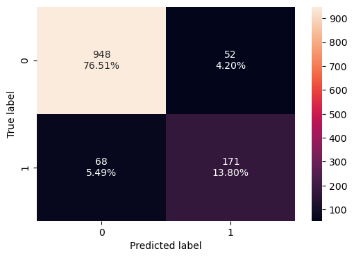

```python
confusion_matrix_sklearn(dtree, X_test, y_test)
```

```python
dtree_model_train_perf=model_performance_classification_sklearn(dtree, X_train, y_train)
print("Training performance \n",dtree_model_train_perf)

#training performance appears to be overfit
```

```
Training performance
    Accuracy  Recall  Precision   F1
0       1.0     1.0        1.0  1.0
```

```python
dtree_model_test_perf=model_performance_classification_sklearn(dtree, X_test, y_test)
print("Testing performance \n",dtree_model_test_perf)

# Recall, precision and f1 are low and could use some tuning.
```

```
Testing performance
    Accuracy    Recall  Precision       F1
0  0.903148  0.715481   0.766816  0.74026
```

# Bagging Classifier

```python
bagging = BaggingClassifier(random_state=1)
bagging.fit(X_train,y_train)
```

```
BaggingClassifier(random_state=1)
```

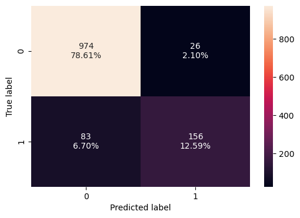

```python
confusion_matrix_sklearn(bagging, X_test, y_test)
```

```python
bagging_model_train_perf=model_performance_classification_sklearn(bagging, X_train, y_train)
print("Training performance \n",bagging_model_train_perf)
```

```
Training performance
    Accuracy    Recall  Precision        F1
0  0.992385  0.964158   0.996296  0.979964
```

Using the bagging classifier the model is slightly less overfit but still overfit. You can tell by looking at the Recall in the example below.

```python
bagging_model_test_perf=model_performance_classification_sklearn(bagging, X_test, y_test)
print("Testing performance \n",bagging_model_test_perf)
```

```
Testing performance
    Accuracy   Recall  Precision        F1
0  0.912026  0.65272   0.857143  0.741093
```

F1 Score is low and quite a bit off from the f1 in teh training set

#### Bagging Classifier with weighted decision tree

```python
bagging_wt = BaggingClassifier(base_estimator=DecisionTreeClassifier(criterion='gini',class_weight={0:0.17,1:0.83},random_state=1),random_state=1)
bagging_wt.fit(X_train,y_train)
```

```
BaggingClassifier(base_estimator=DecisionTreeClassifier(class_weight={0: 0.17,
                                                                      1: 0.83},
                                                        random_state=1),
                  random_state=1)
```

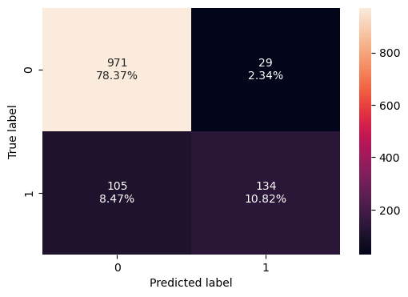

```python
confusion_matrix_sklearn(bagging_wt,X_test,y_test)
```

```python
bagging_wt_model_train_perf=model_performance_classification_sklearn(bagging_wt,X_train,y_train)
print("Training performance \n",bagging_wt_model_train_perf)
```

```
Training performance
    Accuracy    Recall  Precision        F1
0  0.992385  0.962366   0.998141  0.979927
```

```python
bagging_wt_model_test_perf=model_performance_classification_sklearn(bagging_wt, X_test, y_test)
print("Testing performance \n",bagging_wt_model_test_perf)
```

```
Testing performance
    Accuracy    Recall  Precision        F1
0  0.891848  0.560669   0.822086  0.666667
```

The bagging does not appear to improve the F1 nor any other measure of accuracy

### Random Forest

```python
rf = RandomForestClassifier(random_state=1)
rf.fit(X_train,y_train)
```

```
RandomForestClassifier(random_state=1)
```

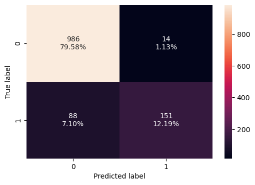

```python
confusion_matrix_sklearn(rf,X_test,y_test)
```

```python
rf_model_train_perf=model_performance_classification_sklearn(rf,X_train,y_train)
print("Training performance \n",rf_model_train_perf)
```

```
Training performance
    Accuracy  Recall  Precision   F1
0       1.0     1.0        1.0  1.0
```

Again the random forest has the issue of overfitting

```python
rf_model_test_perf=model_performance_classification_sklearn(rf,X_test,y_test)
print("Testing performance \n",rf_model_test_perf)
```

```
Testing performance
    Accuracy    Recall  Precision        F1
0  0.917676  0.631799   0.915152  0.747525
```

Precision and accuracy look good but recall and f1 are low

#### Random Forest with Class Weight

```python
rf_wt = RandomForestClassifier(class_weight={0:0.17,1:0.83}, random_state=1)
rf_wt.fit(X_train,y_train)
```

```
RandomForestClassifier(class_weight={0: 0.17, 1: 0.83}, random_state=1)
```

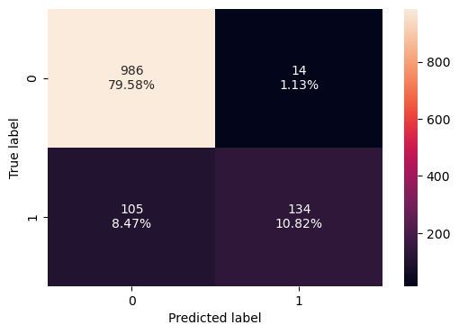

```python
confusion_matrix_sklearn(rf_wt, X_test,y_test)
```

```python
rf_wt_model_train_perf=model_performance_classification_sklearn(rf_wt, X_train,y_train)
print("Training performance \n",rf_wt_model_train_perf)
```

```
Training performance
    Accuracy  Recall  Precision   F1
0       1.0     1.0        1.0  1.0
```

```python
rf_wt_model_test_perf=model_performance_classification_sklearn(rf_wt, X_test,y_test)
print("Testing performance \n",rf_wt_model_test_perf)
```

```
Testing performance
    Accuracy    Recall  Precision        F1
0  0.903955  0.560669   0.905405  0.692506
```

```python
# Experimenting with Tweaking Hyperparameter Tuning
```

```python
# Choose the type of classifier.
dtree_estimator = DecisionTreeClassifier(random_state=1)

# Grid of parameters to choose from
parameters = {'max_depth': np.arange(2,30),
              'min_samples_leaf': [1, 2, 5, 7, 10],
              'max_leaf_nodes' : [2, 3, 5, 10,15, None],
              'min_impurity_decrease': [0.0001,0.001,0.01,0.1]
             }

# Type of scoring used to compare parameter combinations
scorer = metrics.make_scorer(metrics.recall_score)

# Run the grid search
grid_obj = GridSearchCV(dtree_estimator, parameters, scoring=scorer)
grid_obj = grid_obj.fit(X_train, y_train)

# Set the clf to the best combination of parameters
dtree_estimator = grid_obj.best_estimator_

# Fit the best algorithm to the data.
dtree_estimator.fit(X_train, y_train)
```

```
DecisionTreeClassifier(max_depth=21, min_impurity_decrease=0.0001,
                       random_state=1)
```

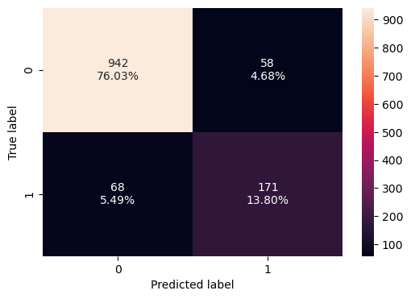

```python
confusion_matrix_sklearn(dtree_estimator, X_test,y_test)
```

```python
dtree_estimator_model_train_perf=model_performance_classification_sklearn(dtree_estimator, X_train,y_train)
print("Training performance \n",dtree_estimator_model_train_perf)
```

```
Training performance
    Accuracy    Recall  Precision        F1
0  0.995154  0.976703   0.998168  0.987319
```

Less overfitting here in training compared to previous methods.

```python
dtree_estimator_model_test_perf=model_performance_classification_sklearn(dtree_estimator, X_test, y_test)
print("Testing performance \n",dtree_estimator_model_test_perf)
```

```
Testing performance
    Accuracy    Recall  Precision        F1
0  0.898305  0.715481   0.746725  0.730769
```

The recall and f1 were brought up but precision degreed which is reasonable.

```python
# grid search for bagging classifier
cl1 = DecisionTreeClassifier(random_state=1)
param_grid = {'base_estimator':[cl1],
              'n_estimators':[5,7,15,51,101],
              'max_features': [0.7,0.8,0.9,1]
             }

grid = GridSearchCV(BaggingClassifier(random_state=1,bootstrap=True), param_grid=param_grid, scoring = 'recall', cv = 5)
grid.fit(X_train, y_train)
```

```
GridSearchCV(cv=5, estimator=BaggingClassifier(random_state=1),
             param_grid={'base_estimator': [DecisionTreeClassifier(random_state=1)],
                         'max_features': [0.7, 0.8, 0.9, 1],
                         'n_estimators': [5, 7, 15, 51, 101]},
             scoring='recall')
```

```python
## getting the best estimator
bagging_estimator  = grid.best_estimator_
bagging_estimator.fit(X_train,y_train)
```

```
BaggingClassifier(base_estimator=DecisionTreeClassifier(random_state=1),
                  max_features=0.9, n_estimators=101, random_state=1)
```

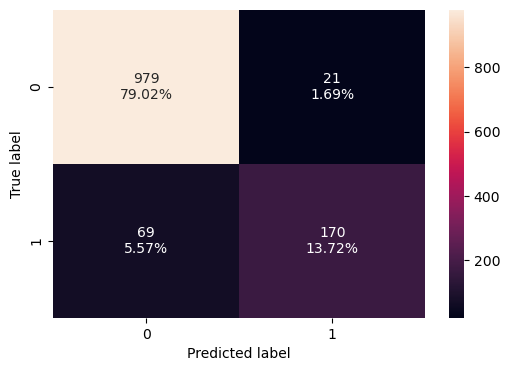

```python
confusion_matrix_sklearn(bagging_estimator, X_test,y_test)
```

```python
bagging_estimator_model_train_perf=model_performance_classification_sklearn(bagging_estimator, X_train,y_train)
print("Training performance \n",bagging_estimator_model_train_perf)
```

```
Training performance
    Accuracy  Recall  Precision   F1
0       1.0     1.0        1.0  1.0
```

Again there is overfitting in the above training but the overall testing data was raised a bit. 92% accuracy is good and Precision looks like it went up.

```python
bagging_estimator_model_test_perf=model_performance_classification_sklearn(bagging_estimator, X_test, y_test)
print("Testing performance \n",bagging_estimator_model_test_perf)
```

```
Testing performance
    Accuracy    Recall  Precision        F1
0  0.927361  0.711297   0.890052  0.790698
```

```python
feature_names = X_train.columns
```

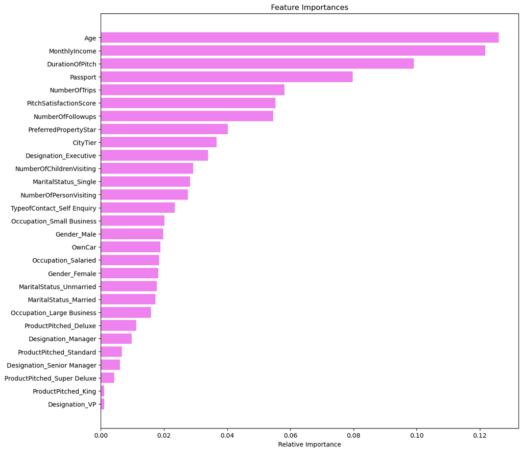

```python
importances = rf.feature_importances_
indices = np.argsort(importances)

plt.figure(figsize=(12,12))
plt.title('Feature Importances')
plt.barh(range(len(indices)), importances[indices], color='violet', align='center')
plt.yticks(range(len(indices)), [feature_names[i] for i in indices])
plt.xlabel('Relative Importance')
plt.show()
```

Above is a list of the most important features

### Boosting

```python
from xgboost import XGBClassifier
from sklearn.tree import DecisionTreeClassifier
from sklearn.ensemble import AdaBoostClassifier, GradientBoostingClassifier
```

Building 3 ensemble models

### AdaBoost Classifier

```python
abc = AdaBoostClassifier(random_state=1)
abc.fit(X_train,y_train)
```

```
AdaBoostClassifier(random_state=1)
```

```python
## Function to create confusion matrix
def make_confusion_matrix(model,y_actual,labels=[1, 0]):
    '''
    model : classifier to predict values of X
    y_actual : ground truth

    '''
    y_predict = model.predict(X_test)
    cm=metrics.confusion_matrix( y_actual, y_predict, labels=[0, 1])
    df_cm = pd.DataFrame(cm, index = [i for i in ["Actual - No","Actual - Yes"]],
                  columns = [i for i in ['Predicted - No','Predicted - Yes']])
    group_counts = ["{0:0.0f}".format(value) for value in
                cm.flatten()]
    group_percentages = ["{0:.2%}".format(value) for value in
                         cm.flatten()/np.sum(cm)]
    labels = [f"{v1}\n{v2}" for v1, v2 in
              zip(group_counts,group_percentages)]
    labels = np.asarray(labels).reshape(2,2)
    plt.figure(figsize = (10,7))
    sns.heatmap(df_cm, annot=labels,fmt='')
    plt.ylabel('True label')
    plt.xlabel('Predicted label')
```

```python
##  Function to calculate different metric scores of the model - Accuracy, Recall and Precision
def get_metrics_score(model,flag=True):
    '''
    model : classifier to predict values of X

    '''
    # defining an empty list to store train and test results
    score_list=[]

    pred_train = model.predict(X_train)
    pred_test = model.predict(X_test)

    train_acc = model.score(X_train,y_train)
    test_acc = model.score(X_test,y_test)

    train_recall = metrics.recall_score(y_train,pred_train)
    test_recall = metrics.recall_score(y_test,pred_test)

    train_precision = metrics.precision_score(y_train,pred_train)
    test_precision = metrics.precision_score(y_test,pred_test)

    score_list.extend((train_acc,test_acc,train_recall,test_recall,train_precision,test_precision))

    # If the flag is set to True then only the following print statements will be dispayed. The default value is set to True.
    if flag == True:
        print("Accuracy on training set : ",model.score(X_train,y_train))
        print("Accuracy on test set : ",model.score(X_test,y_test))
        print("Recall on training set : ",metrics.recall_score(y_train,pred_train))
        print("Recall on test set : ",metrics.recall_score(y_test,pred_test))
        print("Precision on training set : ",metrics.precision_score(y_train,pred_train))
        print("Precision on test set : ",metrics.precision_score(y_test,pred_test))

    return score_list # returning the list with train and test scores
#Using above defined function to get accuracy, recall and precision on train and test set
abc_score=get_metrics_score(abc)
```

```
Accuracy on training set :  0.8497750086535133
Accuracy on test set :  0.8224374495560937
Recall on training set :  0.3942652329749104
Recall on test set :  0.3179916317991632
Precision on training set :  0.6962025316455697
Precision on test set :  0.5714285714285714
```

Recall on precision and test are low for test and training which is poor performing but are close together. We can try to use other boosting techniques to improve performance

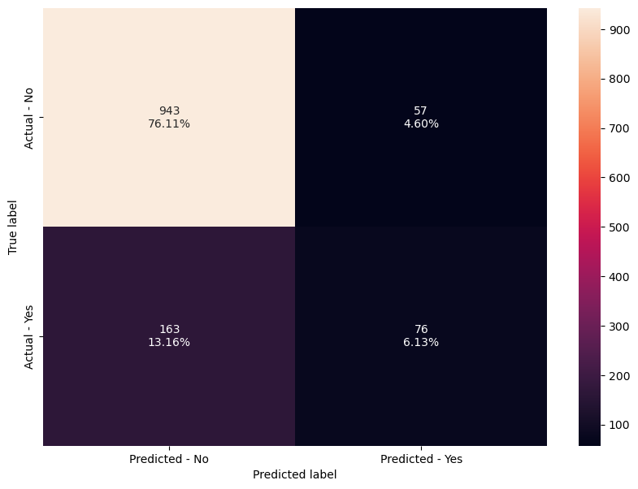

```python
make_confusion_matrix(abc,y_test)
```

### Gradient Boosting Classifier

```python
gbc = GradientBoostingClassifier(random_state=1)
gbc.fit(X_train,y_train)
```

```
GradientBoostingClassifier(random_state=1)
```

```python
#Using above defined function to get accuracy, recall and precision on train and test set
gbc_score=get_metrics_score(gbc)
```

```
Accuracy on training set :  0.9006576670128073
Accuracy on test set :  0.8539144471347861
Recall on training set :  0.5519713261648745
Recall on test set :  0.40585774058577406
Precision on training set :  0.8927536231884058
Precision on test set :  0.7132352941176471
```

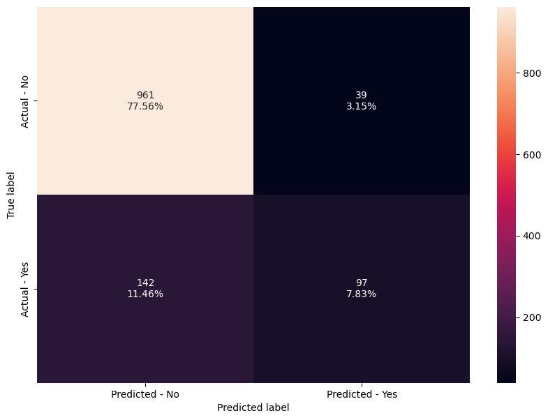

```python
make_confusion_matrix(gbc,y_test)
```

### XGBoost Classifier

```python
xgb = XGBClassifier(random_state=1,eval_metric='logloss')
xgb.fit(X_train, y_train)
```

```
XGBClassifier(base_score=None, booster=None, callbacks=None,
              colsample_bylevel=None, colsample_bynode=None,
              colsample_bytree=None, early_stopping_rounds=None,
              enable_categorical=False, eval_metric='logloss',
              feature_types=None, gamma=None, gpu_id=None, grow_policy=None,
              importance_type=None, interaction_constraints=None,
              learning_rate=None, max_bin=None, max_cat_threshold=None,
              max_cat_to_onehot=None, max_delta_step=None, max_depth=None,
              max_leaves=None, min_child_weight=None, missing=nan,
              monotone_constraints=None, n_estimators=100, n_jobs=None,
              num_parallel_tree=None, predictor=None, random_state=1, ...)
```

```python
#Using above defined function to get accuracy, recall and precision on train and test set
xgb_score=get_metrics_score(xgb)
```

```
Accuracy on training set :  1.0
Accuracy on test set :  0.9160613397901534
Recall on training set :  1.0
Recall on test set :  0.6778242677824268
Precision on training set :  1.0
Precision on test set :  0.8571428571428571
```

XGBoost Here is overfitting on training but teh test accuracy measures are higher.

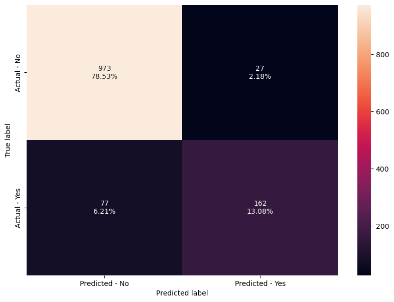

```python
make_confusion_matrix(xgb,y_test)
```

## Hyperparameter Tuning

### AdaBoost Classifier

```python
#This query was taking really long for some reason

# Choose the type of classifier.
abc_tuned = AdaBoostClassifier(random_state=1)

# Grid of parameters to choose from
## add from article
parameters = {
    #Let's try different max_depth for base_estimator
    "base_estimator":[DecisionTreeClassifier(max_depth=1, random_state=1),DecisionTreeClassifier(max_depth=2, random_state=1),DecisionTreeClassifier(max_depth=3, random_state=1)],
    "n_estimators": np.arange(10,110,10),
    "learning_rate":np.arange(0.1,2,0.1)
}

# Type of scoring used to compare parameter combinations
acc_scorer = metrics.make_scorer(metrics.recall_score)

# Run the grid search
grid_obj = GridSearchCV(abc_tuned, parameters, scoring=acc_scorer,cv=5)
grid_obj = grid_obj.fit(X_train, y_train)

# Set the clf to the best combination of parameters
abc_tuned = grid_obj.best_estimator_

# Fit the best algorithm to the data.
abc_tuned.fit(X_train, y_train)
```

[output not shown]

```python
#Using above defined function to get accuracy, recall and precision on train and test set
abc_tuned_score=get_metrics_score(abc_tuned)
```

[output not shown]

```python
make_confusion_matrix(abc_tuned,y_test)
```

[output not shown]

Insights

- Since Age of those who took the package are slightly lower than those who did not.
- It's worth targeting a slightly younger demographic. Number of followups is slighly higher
- Business should followup with people they want to take packages Prefered Property Star holders had a higher number of Packages Taken.
- Business should prioritize reaching out to Prefered Property Star Holders
- It doesn't seem worth it to target divorced people don't seem to be as easily swayed to buy packages and focus should be spent on married and single persons The model we build with the bagging classifier seemed to show an improvement vs the boosting technique